# R Assignment 1

Karen Gao

9/25/2019

```r
# Clear out the environment
rm(list = ls())
# Load relevant libraries, installing them if you haven't already done so
if (!require(tidyverse))
{
  install.packages("tidyverse")
}
library(tidyverse)

# Load the data
vehicles <- read_csv("https://itao-datasets.s3.amazonaws.com/vehicles.csv",
                     col_types="inincicccici")
vehicles <- vehicles %>%
  mutate(class=as.factor(class),
         drive=as.factor(drive),
         make=as.factor(make),
         transmissiontype=as.factor(transmissiontype))
```

## Problem 1: Guided Visualization

### Part A

Generate a scatterplot showing the miles per gallon that the vehicle experiences during city driving on the x-axis and the vehicle’s CO2 emissions on the y-axis.

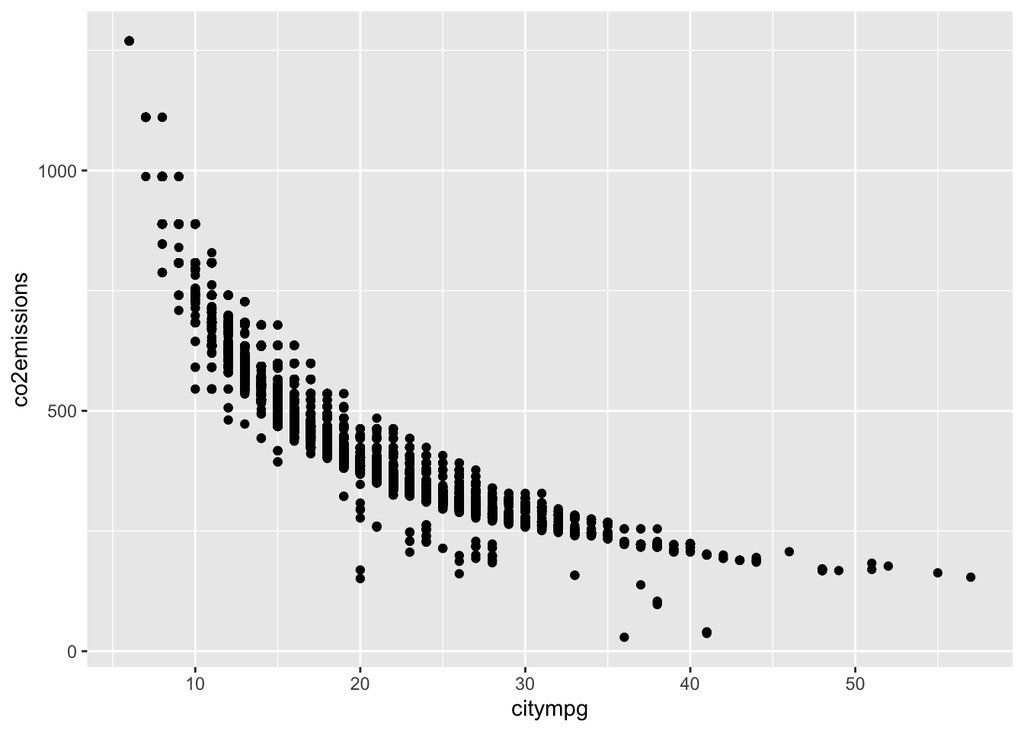

```r
library(ggplot2)
ggplot(data=vehicles) +
  geom_point(mapping=aes(x=citympg,
                         y=co2emissions))
```

### Part B

Create a second scatterplot showing the same information as the plot from Part A but use color to distinguish vehicles by drive type.

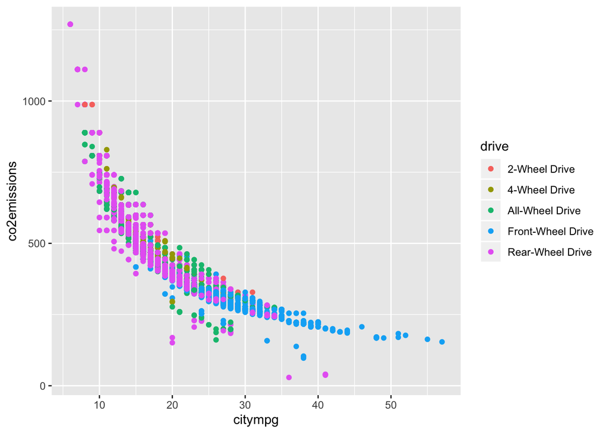

```r
ggplot(data=vehicles) +
  geom_point(mapping=aes(x=citympg,
                         y=co2emissions,
                         color=drive))
```

### Part C

Create a stacked bar chart that shows the number of vehicles tested each year broken out by vehicle class.

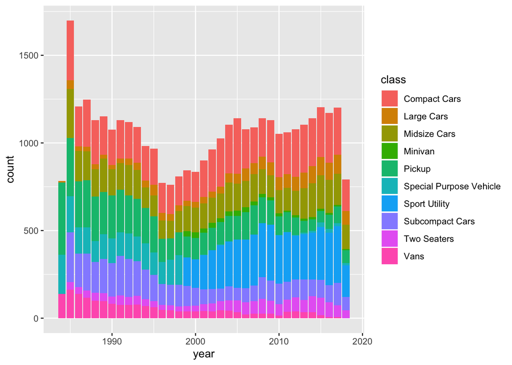

```r
ggplot(data=vehicles) +
  geom_bar(mapping=aes(x=year,
                       fill=class))
```

### Part D

Create a set of histograms that shows the number of vehicles tested by their mileage per gallon during city driving. You should use one call to ggplot that creates separate histograms for each transmission type.

Note: We did not discuss histograms in class, so you may wish to consult the documentation for this geometry. Also, it might simplify things to create a single histogram first and then add commands that break it into different histograms for each transmission type.

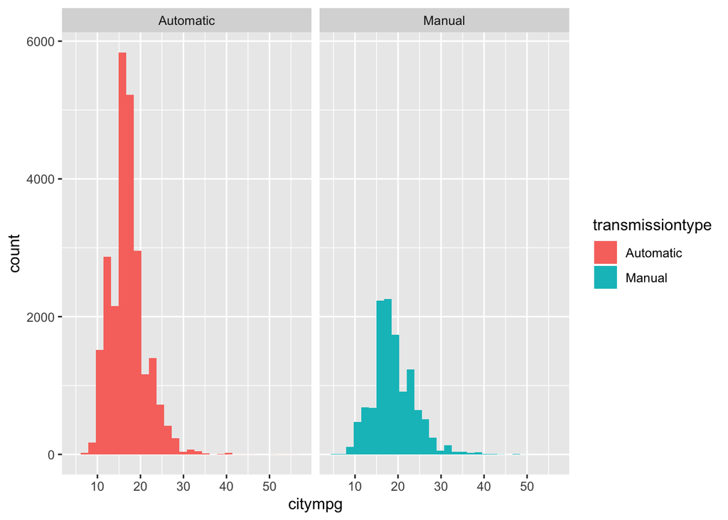

```r
ggplot(data=vehicles) +
  geom_histogram(mapping=aes(x=citympg,
                             fill=transmissiontype))+
    facet_grid( ~ transmissiontype)
```

## Problem 2 - Working with dplyr

In this part of the assignment, you will expand your work to use the dplyr grammar of data manipulation.

For each part below, use a single R statement to perform the task. You may do this by joining together dplyr verbs and the ggplot commands with %>% and +.

### Part A

Print a table showing the minimum, maximum, mean, and median city MPG for vehicles tested, broken out by vehicle class. All values should be displayed as integers. Use the as.integer() and round() functions, as necessary.

```r
library(dplyr)
vehicles%>%
  group_by(class)%>%
  summarise(min=min(citympg),
           med=as.integer(median(citympg)),
           mean=as.integer(round(mean(citympg))),
           max=max(citympg))
```

```
## # A tibble: 10 x 5
##    class                     min   med  mean   max
##    <fct>                   <int> <int> <int> <int>
##  1 Compact Cars                7    20    20    52
##  2 Large Cars                  7    16    16    57
##  3 Midsize Cars                7    18    18    51
##  4 Minivan                    13    16    17    22
##  5 Pickup                      8    15    15    30
##  6 Special Purpose Vehicle     8    15    15    31
##  7 Sport Utility              10    16    17    34
##  8 Subcompact Cars             7    19    20    43
##  9 Two Seaters                 6    16    17    49
## 10 Vans                        8    13    13    23
```

### Part B

Display a line graph showing the change in average city vs. highway MPG over time. Do not round the data to integers this time. Show the city MPG as a red line and the highway MPG as a blue line.

You do not need to add a legend to this diagram. The structure of the data would make this somewhat complicated. We’ll discuss that more when we get to data wrangling.

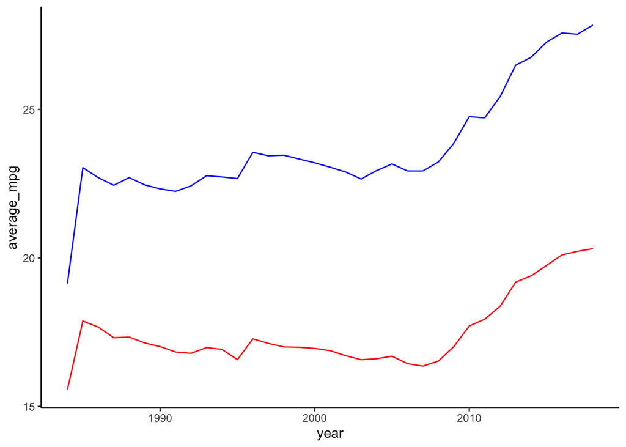

```r
vehicles%>%
  group_by(year)%>%
  summarise(avg_citympg=mean(citympg),avg_highwaympg=mean(highwaympg))%>%
  ggplot()+
  geom_line(mapping=aes(x=year,
                        y=avg_citympg),
                        color='red')+
  geom_line(mapping=aes(x=year,
                        y=avg_highwaympg),
                        color='blue')+
  theme_classic()+
  ylab('average_mpg')
```

### Part C

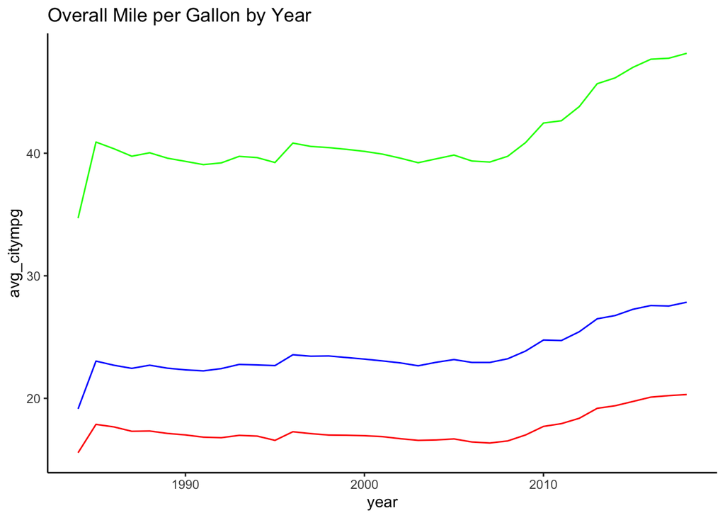

```r
vehicles%>%
  group_by(year)%>%
  summarise(avg_citympg=mean(citympg),
            avg_highwaympg=mean(highwaympg),
            overall_mpg=avg_citympg+avg_highwaympg)%>%
  ggplot()+
  geom_line(mapping=aes(x=year,
                        y=avg_citympg),
                        color='red')+
  geom_line(mapping=aes(x=year,
                        y=avg_highwaympg),
                        color='blue')+
  geom_line(mapping=aes(x=year,
                        y=overall_mpg),
                        color='green')+
  theme_classic()+
  ggtitle('Overall Mile per Gallon by Year')
```

```r
  ylab('average_mpg')
```

```
## $y
## [1] "average_mpg"
##
## attr(,"class")
## [1] "labels"
```

### Part D

Modify the graph above to show separate graphs for each drive type.

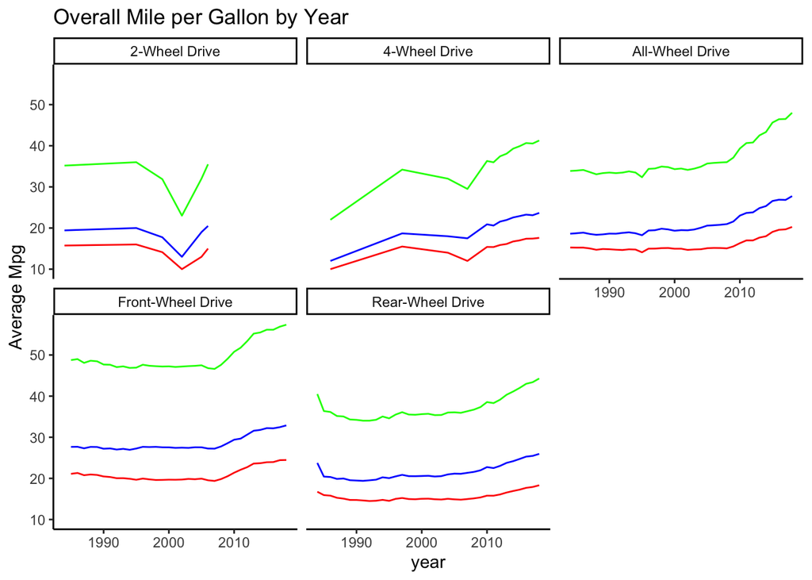

```r
vehicles%>%
  group_by(year,drive)%>%
  summarise(avg_citympg=mean(citympg),
            avg_highwaympg=mean(highwaympg),
            overall_mpg=avg_citympg+avg_highwaympg)%>%
  ggplot()+
  geom_line(mapping=aes(x=year,
                        y=avg_citympg),
                        color='red')+
  geom_line(mapping=aes(x=year,
                        y=avg_highwaympg),
                        color='blue')+
  geom_line(mapping=aes(x=year,
                        y=overall_mpg),
                        color='green')+
  facet_wrap(~drive)+
  theme_classic()+
  ggtitle('Overall Mile per Gallon by Year')+
  ylab('Average Mpg')
```

## Problem 3 - Data Exploration and Visualization

Use the strategies you learned in class as well as your own independent research to explore the vehicle testing and college datasets in more detail.

Create two interesting visualizations based upon your exploration. Take the time to beautify them. Your grade for this portion of the assignment will be based upon your technical ability to create the visualizations, their analytical uniqueness, and their appearance.

Feel free to use the techniques that we explored in class and/or to explore other features of ggplot2.

For each of your visualizations, provide a brief description of the insight that they provide. You should answer the question (with just a sentence or two), “What do we learn from this visualization?” You can provide your answer as comments in your code or, if you would like to explore a new technology, try using RMarkdown.

You may choose to use data from the vehicle dataset, the college dataset, or both.

#The visualizaiton I designed below shows the Admission rate of universities with bechalor and graduate as their highest degree in the state of Illinois. Also,this map allows us to compare the number of two types of univeristies.

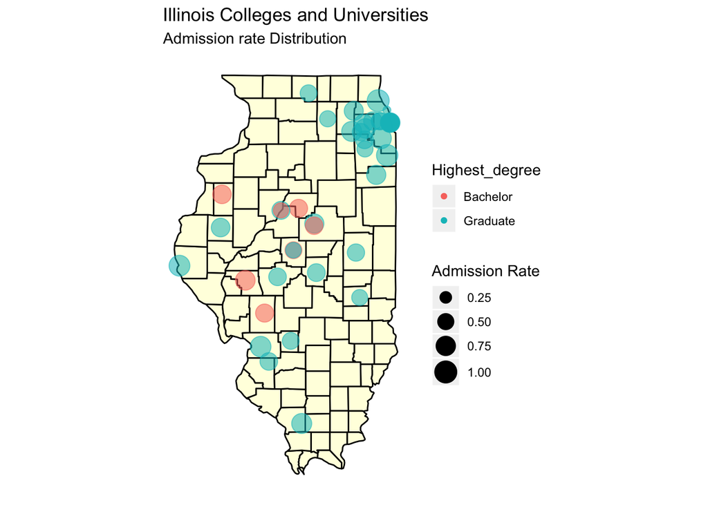

```r
library(tidyverse)
library(ggmap)
library(maps)
library(mapproj)

college <- read_csv("https://s3.amazonaws.com/itao-datasets/college.csv")
college <- college %>%
  mutate(state=as.factor(state), region=as.factor(region),
         highest_degree=as.factor(highest_degree),control=
         as.factor(control),gender=as.factor(gender),loan_default_rate
         =as.numeric(loan_default_rate))

IL_colleges = college %>%
  filter(state=='IL')
IL_mapdata <- map_data(map="county", region="Illinois")

ggplot()+
  geom_polygon(data=IL_mapdata,aes(x=long,
                                   y=lat,
                                   group=group),
                                   color='black',
                                   fill='lightyellow1')+
  coord_map()+
  geom_point(data=IL_colleges,aes(x=lon,
                                  y=lat,
                                  color=highest_degree,
                                  size=admission_rate,
                                  alpha=0.89))+
  theme(panel.grid=element_blank(),
        panel.background=element_blank(),
        axis.ticks=element_blank(),
        axis.text=element_blank(),
        axis.title = element_blank())+
  ggtitle("Illinois Colleges and Universities",
          subtitle='Admission rate Distribution')+
  scale_alpha_continuous(guide=FALSE)+
  scale_color_discrete(name='Highest_degree')+
  scale_size_continuous(name='Admission Rate',range=c(1,7))
```

#I using the graphs below to show the relationship between loan default rate and the sat score. We could find that high sat score is associate with low loan defualt rate in each of the four regions. Also, I used gradient color to illustrate the number of schools in the graph.

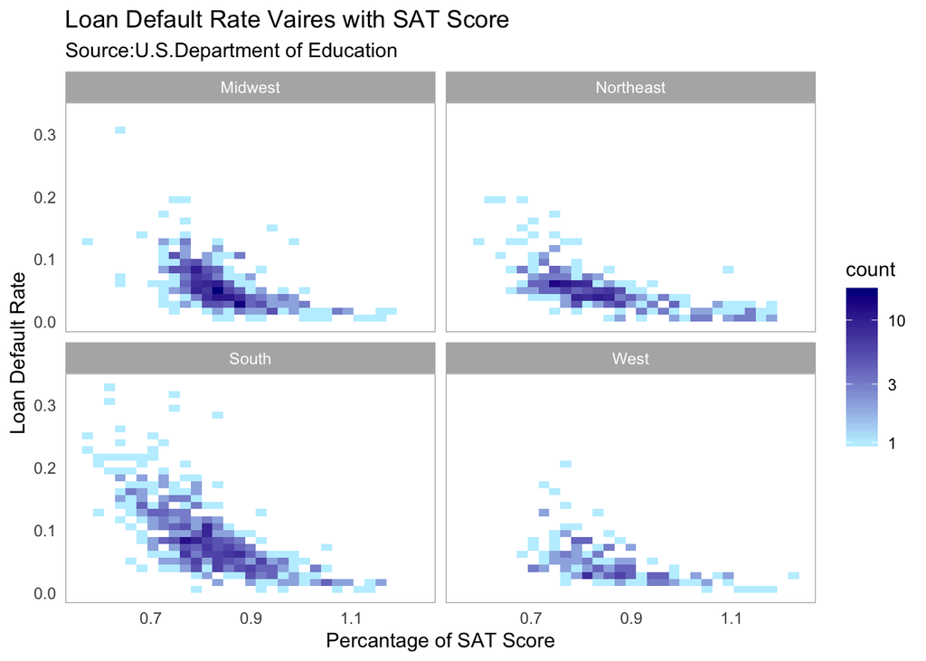

```r
college%>%
  mutate(high_score_percentage=sat_avg/n())%>%
  ggplot(mapping=aes(x=high_score_percentage,
                     y=loan_default_rate))+
  geom_bin2d(bins=30)+
  facet_wrap(~region)+
  scale_fill_gradient(low="lightblue1",high="darkblue",trans="log10")+
  theme_light()+
  theme(axis.ticks=element_blank(),
        panel.grid=element_blank(),
        panel.background=element_blank())+
  ylab("Loan Default Rate")+
  xlab("Percantage of SAT Score")+
  ggtitle("Loan Default Rate Vaires with SAT Score",
          subtitle='Source:U.S.Department of Education')
```